# 3) Exploring CFIT Using Item Response Theory Models

2026-06-29

```r
knitr::opts_chunk$set(echo = FALSE)
knitr::opts_chunk$set(message = FALSE)
knitr::opts_chunk$set(comment = NULL)
knitr::opts_chunk$set(warning = FALSE)
```

```r
library(tidyverse)
library(psych)
library(gt)
library(mirt) # mirt()
library(kableExtra)
library(caret) #findCorrelation()
library(ggmirt)  #testInfoPlot()
library(patchwork)
```

# Reading in the CFIT data

The CFIT Scale 2 Form B is a **timed** non-verbal fluid intelligence test. It contains 46 items and 4-subscales:

- Series (12 items)
- Classifications (14 items)
- Matrices (12 items)
- Conditions (8 items)

### Missing Data

We are quickly going to group items by subtest to assess for missing data. We will not remove anyone for having missing data since the IRT models are expected to be able to handle this.

```
$series
[1] 0

$classification
[1] 0

$matrices
[1] 0

$conditions
[1] 0
```

Descriptive Statistics of CFIT Performance Score

| vars | n | mean | sd | median | trimmed | mad | min | max | range | skew | kurtosis | se |
| --- | --- | --- | --- | --- | --- | --- | --- | --- | --- | --- | --- | --- |
| 1 | 634 | 29.96 | 6.65 | 32 | 30.63 | 5.93 | 1 | 42 | 41 | -0.97 | 0.82 | 0.26 |

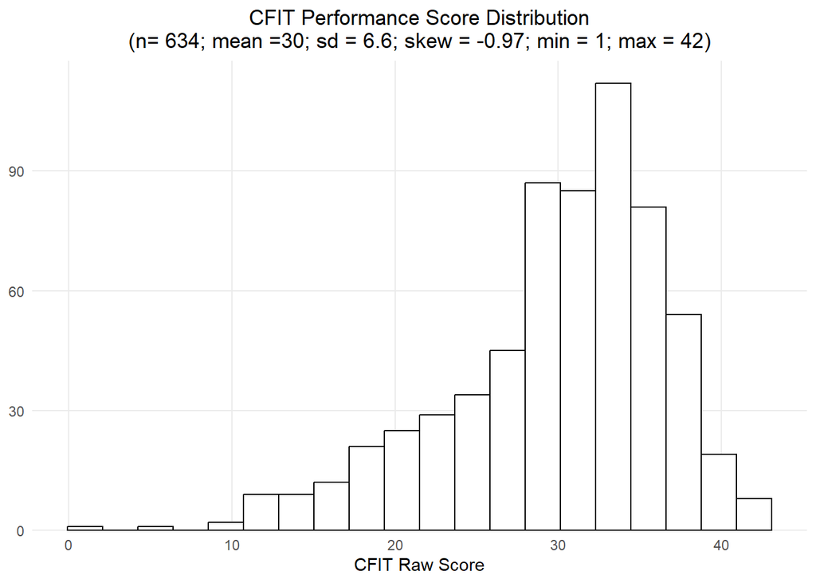

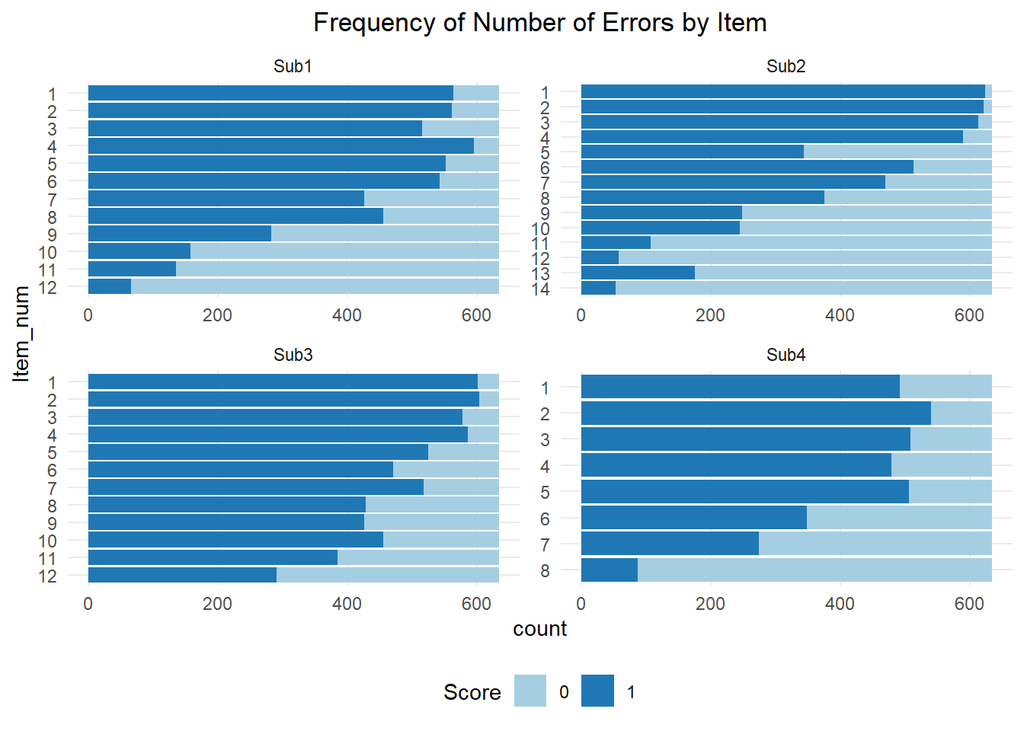

We have the code to show the proportion of incorrect and correct items for the CFIT- but it is a long table and it does not provide us any useful information that we can’t already infer from the previous plots.

```r
# Create a gt() table for our CFIT response probabilities
Table1A <- CFIT_response_prob_wide %>%
  gt() %>%
  tab_options(
    table.font.size = 11,           # make tighter if needed
    table.width = pct(45)           # helps side-by-side fit
  ) %>%
  tab_header(
    title = "A: CFIT Subtest Probability of Response Category Endorsement by Item"   # Required: your main title
  )
# Table1A
```

Technically a parallel analysis is better but I don’t really care tbh. The main takeaway is most of the variance is explained by one factor, but there is evidence in the data present for a few very weak factors, which likely correspond to question similarity, since questions correspond to one of four subtests named: series, classification, matrices, conditions.

```
                            MR1        MR2       MR4        MR3        MR5
SS loadings           5.6393108 4.53256019 4.4887488 3.62105732 2.13737378
Proportion Var        0.1225937 0.09853392 0.0975815 0.07871864 0.04646465
Cumulative Var        0.1225937 0.22112763 0.3187091 0.39742776 0.44389241
Proportion Explained  0.2761789 0.22197703 0.2198314 0.17733720 0.10467547
Cumulative Proportion 0.2761789 0.49815592 0.7179873 0.89532453 1.00000000
```

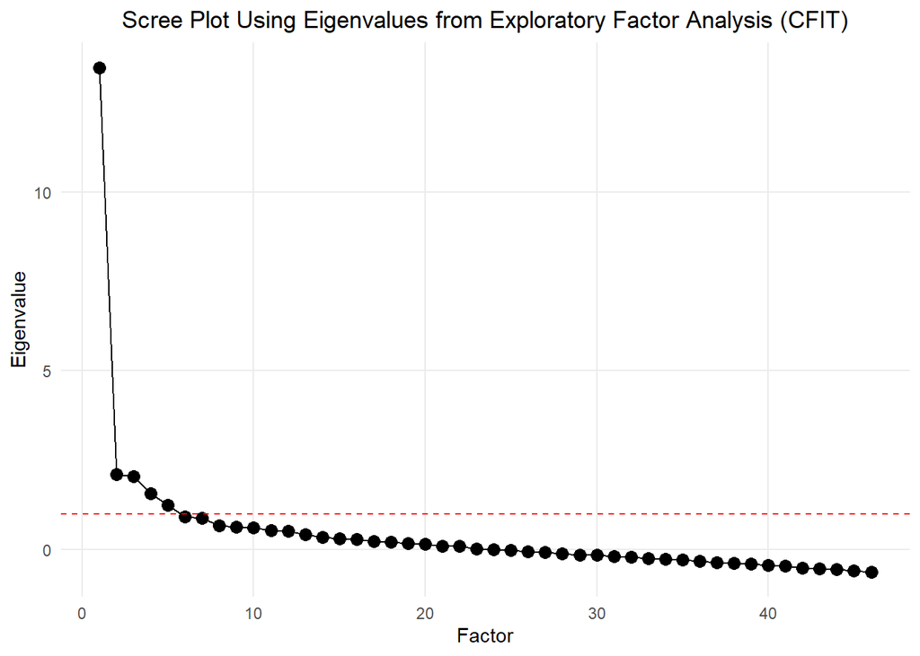

### Running a 2PL, 4-factor 2PL, and Bi-Factor 2PL Model on the CFIT Data

We chose not to fit a hierarhical model because a) it failed to converge (producing an error) and b) theoretically it is not that good of a representation of IQ.

From the model comparison below, the Bi-Factor model produced the best fit (lowest AIC & BIC)

We don’t care for the likelihood ratio tests below- what we are interested in is the AIC and BIC values, in which we see that the bi-factor model is the best fitting model for the data.

Model Fit Indices of the three CFIT IRT Models (First Round)

|  | AIC | SABIC | HQ | BIC | logLik | X2 | df | p |
| --- | --- | --- | --- | --- | --- | --- | --- | --- |
| CFIT_2pl | 24482.08 | 24599.58 | 24641.13 | 24891.67 | -12149.04 | NA | NA | NA |
| CFIT_4factor | 25949.00 | 26074.16 | 26118.42 | 26385.30 | -12876.50 | -1454.924 | 6 | NaN |
| CFIT_bifactor | 24057.15 | 24233.40 | 24295.72 | 24671.53 | -11890.58 | 1971.852 | 40 | 0 |

### Printing Bi-Factor Model Output Summary (Problematic)

We used the coef() function to produce discrimination (a) slopes for each item that correspond to the general factor and the specific-factor (question type). We do see some problems, in that some items have very very low slopes! (below 1). Thus, we should go ahead and remove these items.

| Series Item Num. | Series a1 | Series a2 | Series a3 | Series a4 | Series a5 | Series b | Classifications Item Num. | Classifications a1 | Classifications a2 | Classifications a3 | Classifications a4 | Classifications a5 | Classifications b | Matrices Item Num. | Matrices a1 | Matrices a2 | Matrices a3 | Matrices a4 | Matrices a5 | Matrices b | Conditions Item Num. | Conditions a1 | Conditions a2 | Conditions a3 | Conditions a4 | Conditions a5 | Conditions b |
| --- | --- | --- | --- | --- | --- | --- | --- | --- | --- | --- | --- | --- | --- | --- | --- | --- | --- | --- | --- | --- | --- | --- | --- | --- | --- | --- | --- |
| 1 | 1.06 | 1.28 | 0 | 0 | 0 | 2.95 | 1 | 1.85 | 0 | 0.73 | 0 | 0 | 5.87 | 1 | 1.78 | 0 | 0 | 0.64 | 0 | 4.29 | 1 | 1.53 | 0 | 0 | 0 | 1.84 | 2.28 |
| 2 | 1.9 | 1.41 | 0 | 0 | 0 | 3.54 | 2 | 1.58 | 0 | 1.03 | 0 | 0 | 5.51 | 2 | 1.39 | 0 | 0 | 1.09 | 0 | 4.26 | 2 | 2.93 | 0 | 0 | 0 | 5.02 | 6.41 |
| 3 | 0.69 | 0.43 | 0 | 0 | 0 | 1.65 | 3 | 1.64 | 0 | 0.98 | 0 | 0 | 4.92 | 3 | 1.21 | 0 | 0 | 0.65 | 0 | 3.02 | 3 | 2.49 | 0 | 0 | 0 | 2.21 | 3.28 |
| 4 | 2.54 | 1.79 | 0 | 0 | 0 | 5.62 | 4 | 0.95 | 0 | 0.70 | 0 | 0 | 3.15 | 4 | 3.26 | 0 | 0 | 4.06 | 0 | 7.96 | 4 | 1.82 | 0 | 0 | 0 | 1.01 | 1.9 |
| 5 | 1.7 | 1.25 | 0 | 0 | 0 | 3.09 | 5 | 0.21 | 0 | -0.09 | 0 | 0 | 0.17 | 5 | 1.84 | 0 | 0 | 0.93 | 0 | 2.56 | 5 | 2.14 | 0 | 0 | 0 | 1.47 | 2.67 |
| 6 | 1.93 | 1.12 | 0 | 0 | 0 | 3.02 | 6 | 1.06 | 0 | 0.54 | 0 | 0 | 1.81 | 6 | 1.45 | 0 | 0 | 0.78 | 0 | 1.54 | 6 | 0.73 | 0 | 0 | 0 | 0.32 | 0.22 |
| 7 | 2.01 | 1.22 | 0 | 0 | 0 | 1.25 | 7 | 0.53 | 0 | 1.27 | 0 | 0 | 1.41 | 7 | 1.21 | 0 | 0 | 0.51 | 0 | 1.95 | 7 | 0.86 | 0 | 0 | 0 | 0.85 | -0.35 |
| 8 | 1.35 | 1.19 | 0 | 0 | 0 | 1.42 | 8 | 1.33 | 0 | 0.21 | 0 | 0 | 0.48 | 8 | 1.33 | 0 | 0 | 0.4 | 0 | 0.99 | 8 | -0.03 | 0 | 0 | 0 | 0.29 | -1.86 |
| 9 | 0.74 | 0.75 | 0 | 0 | 0 | -0.27 | 9 | 0.70 | 0 | -0.55 | 0 | 0 | -0.51 | 9 | 1.43 | 0 | 0 | 0.16 | 0 | 0.97 |  |  |  |  |  |  |  |
| 10 | 0.32 | 0.33 | 0 | 0 | 0 | -1.15 | 10 | 0.60 | 0 | -0.62 | 0 | 0 | -0.54 | 10 | 1.76 | 0 | 0 | 0.44 | 0 | 1.42 |  |  |  |  |  |  |  |
| 11 | 0.29 | 0.53 | 0 | 0 | 0 | -1.4 | 11 | 0.60 | 0 | 0.46 | 0 | 0 | -1.77 | 11 | 1.02 | 0 | 0 | 0.06 | 0 | 0.52 |  |  |  |  |  |  |  |
| 12 | 0.31 | 0 | 0 | 0 | 0 | -2.19 | 12 | 0.23 | 0 | -0.39 | 0 | 0 | -2.38 | 12 | 0.89 | 0 | 0 | -0.07 | 0 | -0.2 |  |  |  |  |  |  |  |
|  |  |  |  |  |  |  | 13 | 0.68 | 0 | 0.07 | 0 | 0 | -1.05 |  |  |  |  |  |  |  |  |  |  |  |  |  |  |
|  |  |  |  |  |  |  | 14 | 0.72 | 0 | 0.37 | 0 | 0 | -2.64 |  |  |  |  |  |  |  |  |  |  |  |  |  |  |

### Removing Problematic Items (Low Slopes) and Re-running a Unidimensional and Bi-Factor Model

From the results above, the coefficients for each item, we decided to remove the following items: - subtest1: 3, 9, 10, 11, 12 - subtest2: 4, 5, 7, 9, 10, 11, 12, 13, 14 - subtest3: 12 - subtest4: 6, 7, 8

Looks like the bi-factor model failed to converge so we will go with the undimensional 2PL version

While the bi-factor model **DOES PRODUCE BETTER FIT INDICIES**- THE MODEL **FAILED TO CONVERGE** UP to 2,500 ITERATIONS. It seems that the Max-Change value is just stuck in some local maxima.

Model Fit Indices of the three CFIT IRT Models (Second Round)

|  | AIC | SABIC | HQ | BIC | logLik | X2 | df | p |
| --- | --- | --- | --- | --- | --- | --- | --- | --- |
| CFIT_2pl_rmvItms | 12825.66 | 12897.18 | 12922.48 | 13074.98 | -6356.831 | NA | NA | NA |
| CFIT_4factor_rmvItems | 12899.66 | 12978.84 | 13006.85 | 13175.69 | -6387.831 | -61.999 | 6 | NaN |
| CFIT_bifactor_rmvItems | 12480.24 | 12587.52 | 12625.46 | 12854.21 | -6156.120 | 463.421 | 22 | 0 |

### Local Dependence Check on the Unidimensional CFIT Model

There is local dependence for the undimensional model (not good)

Below is the list of items that have local dependence with another item on the list

```
[1] 25 26 28  3  4  6 10  9
```

### Removing Items with Local Dependence

To address the local dependence problem, we will be removing items based on the results above. Right now the problematic item pairs are:

Problematic row pairs (correlations)

- row 25 & 26
- row 26 & 24
- row 28 & 6
- row 3 & 4
- row 4 & 8
- row 6 & 7
- row 8 & 10
- row 8 & 9
- row 14 and 13

We will remove the following rows/items:

- Remove: row 26: Sub4_3
- Remove: row 6: Sub1_7
- Remove: row 4: Sub1_5
- Remove: row 8: Sub2_1
- Remove: row 13: Sub3_1

Second round! There was still local depedence after the initial removal of items above, so we also removed these items as well:

- Remove: Sub4_1
- Remove: Sub4_2
- Remove: Sub1_4

There are no LD item pairs in the 2PL model after having several items removed

```
integer(0)
```

#### Final 2PL CFIT Model Parameters

We lost quite a bit of items! But that should not be true problematic assuming that we still have good coverage for the information/conditional reliability curves.

Final Items of the CFIT 2PL Model

| Series Item Num. | Series a | Series b | Classifications Item Num. | Classifications a | Classifications b | Matrices Item Num. | Matrices a | Matrices b | Conditions Item Num. | Conditions a | Conditions b |
| --- | --- | --- | --- | --- | --- | --- | --- | --- | --- | --- | --- |
| 1 | 1.21 | -2.15 | 2 | 1.66 | -3.09 | 2 | 1.52 | -2.61 | 4 | 1.47 | -1.06 |
| 2 | 1.88 | -1.65 | 3 | 1.79 | -2.64 | 3 | 1.26 | -2.32 | 5 | 1.57 | -1.24 |
| 6 | 1.92 | -1.45 | 6 | 1.03 | -1.69 | 4 | 2.12 | -1.90 |  |  |  |
| 8 | 1.24 | -0.98 | 8 | 1.14 | -0.4 | 5 | 1.94 | -1.28 |  |  |  |
|  |  |  |  |  |  | 6 | 1.56 | -0.96 |  |  |  |
|  |  |  |  |  |  | 7 | 1.32 | -1.48 |  |  |  |
|  |  |  |  |  |  | 8 | 1.33 | -0.73 |  |  |  |
|  |  |  |  |  |  | 9 | 1.35 | -0.71 |  |  |  |
|  |  |  |  |  |  | 10 | 1.77 | -0.80 |  |  |  |
|  |  |  |  |  |  | 11 | 0.96 | -0.53 |  |  |  |

M2 Model Fit Plus Other Fit Indices for Final 2PL

|  | M2 | df | p | RMSEA | RMSEA_5 | RMSEA_95 | SRMSR | TLI | CFI |
| --- | --- | --- | --- | --- | --- | --- | --- | --- | --- |
| stats | 272.0864 | 170 | 0 | 0.0308 | 0.0238 | 0.0374 | 0.0483 | 0.9802 | 0.9823 |

Item level diagnostics all look good! No item has a p-value less than 0.001

Item Level Diagnostics for Final 2PL CFIT Model

| item | S_X2 | df.S_X2 | RMSEA.S_X2 | p.S_X2 |
| --- | --- | --- | --- | --- |
| Sub1_1 | 9.4123 | 14 | 0.0000 | 0.8038 |
| Sub1_2 | 15.4522 | 12 | 0.0213 | 0.2176 |
| Sub1_6 | 14.6869 | 12 | 0.0188 | 0.2590 |
| Sub1_8 | 17.9132 | 12 | 0.0279 | 0.1184 |
| Sub2_2 | 2.2100 | 5 | 0.0000 | 0.8194 |
| Sub2_3 | 8.5872 | 8 | 0.0108 | 0.3783 |
| Sub2_6 | 22.1306 | 13 | 0.0333 | 0.0534 |
| Sub2_8 | 9.9450 | 11 | 0.0000 | 0.5353 |
| Sub3_2 | 7.5059 | 13 | 0.0000 | 0.8742 |
| Sub3_3 | 8.6139 | 14 | 0.0000 | 0.8550 |
| Sub3_4 | 15.3586 | 11 | 0.0250 | 0.1667 |
| Sub3_5 | 22.8226 | 12 | 0.0377 | 0.0293 |
| Sub3_6 | 16.3455 | 12 | 0.0239 | 0.1759 |
| Sub3_7 | 14.5125 | 13 | 0.0136 | 0.3388 |
| Sub3_8 | 19.8928 | 11 | 0.0357 | 0.0468 |
| Sub3_9 | 11.2990 | 11 | 0.0066 | 0.4186 |
| Sub3_10 | 17.8926 | 11 | 0.0315 | 0.0841 |
| Sub3_11 | 14.8893 | 12 | 0.0195 | 0.2475 |
| Sub4_4 | 18.6758 | 12 | 0.0296 | 0.0967 |
| Sub4_5 | 21.5249 | 12 | 0.0354 | 0.0432 |

### Information and Conditional Reliability Curve Shows Good Coverage for Lower Fluid Intelligence Ability

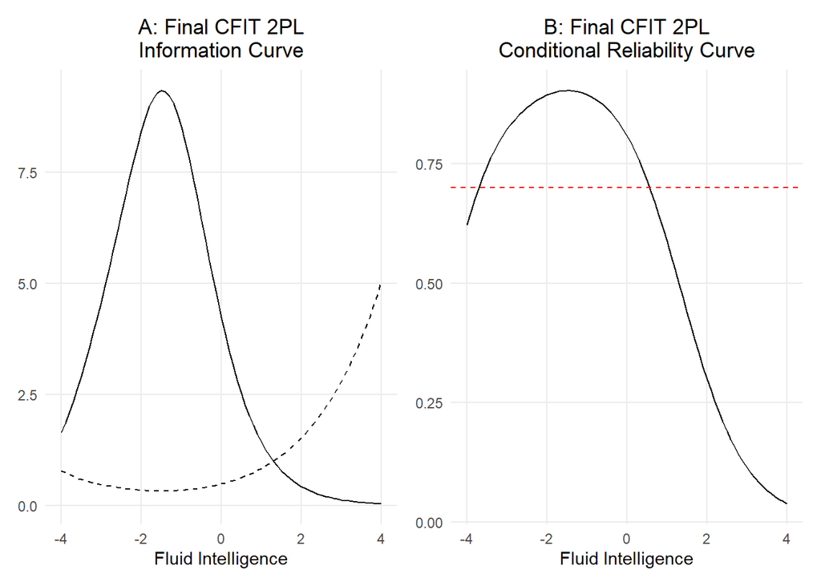

```
Reliability of .7 is present between -3.7 and 0.5 theta values
```

```
Reliability of .8 is present between -3.1 and 0 theta values
```

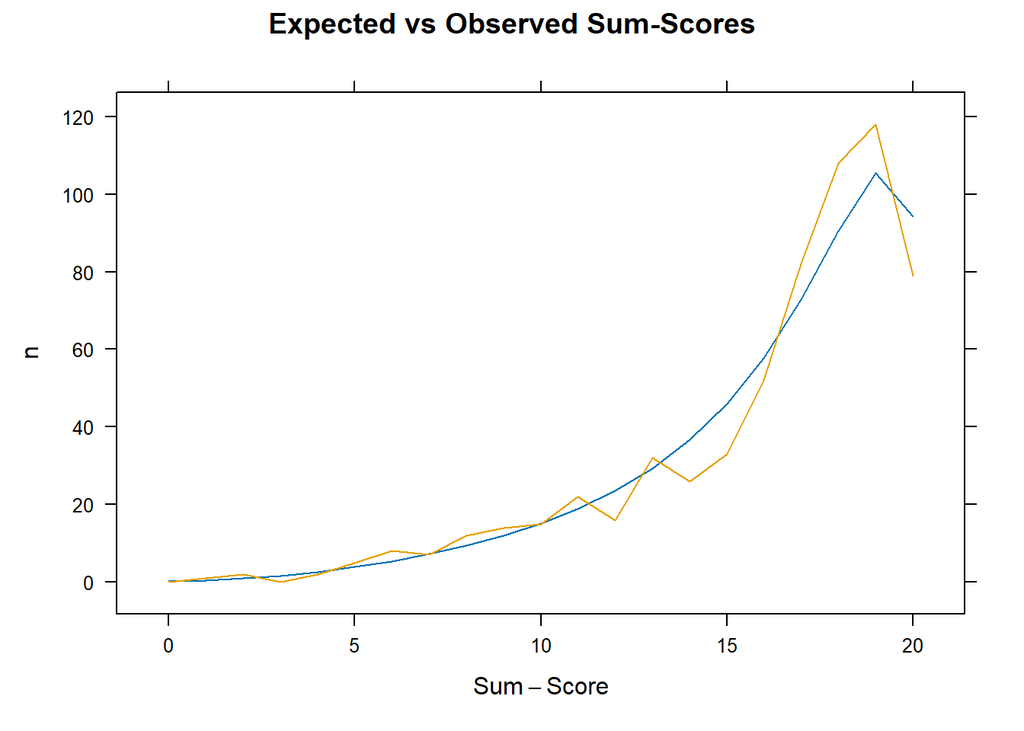

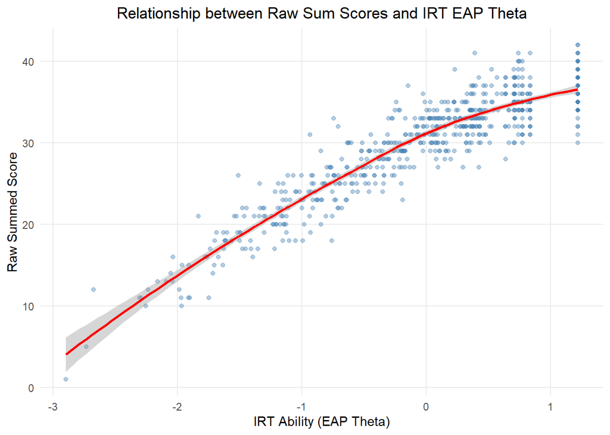

```
The correlation between raw scores and EAP scores is: 0.91
```

```r
# Change the working directory
setwd(clean_data_output)

# Save the ARFA data with the IRT scores
saveRDS(EAP_df, "3_CFIT_eap.rds")
```